[figure not shown]

# Session 1: Introduction and Orientation

## Data Structures and Algorithm 1 - Lab

### Yahya Tawil

### Fri, 24 Sep 2021

# Introduction

- How is me?
- Contact me: yahya.tawil@gmail.com **or** yahya.tawil@std.hku.edu.tr

# Introduce yourselfs: Name - Which year - Programming languages you know.

- This lecture is to make you exited about computer Algorithms

# What is an algorithm?

## Real Life Example (anaology):

[figure not shown]

## More Complicated:

[figure not shown]

# As a broad answer: “A set of steps to accomplish a task.“

## What if the problem is more complicated in real life?

# What is a **computer** algorithm?

# A computer algorithm is any well-defined computational procedure that takes some value, or set of values, as input and produces some value, or set of values, as output.

# Thus, an algorithm is a sequence of computational steps that transform the input into the output.

# Applications of Algorithms in Many Branches in Computer Science

## GPS Maps : Shortest Path (Graph Algorithms)

[figure not shown]

* source: getcircuit.com

## Routing in Computers Networks : Shortest Path (Graph Algorithms)

[figure not shown]

* sourse: Wikimedia

## Databases : Tree Datastructure (Searching algorithms)

[figure not shown]

## Biology : Compare Biological Sequences(Dynamic Programming)

[figure not shown]

## Cryptography : Public Key(Prime Number Generation)

[figure not shown]

# Example: Grade-school Algorithm (long multiplication algorithm)

[figure not shown]

## For now, let’s think of a primitive operation as any of the following:

1. adding two single-digit numbers.
2. multiplying two single-digit numbers.
3. adding a zero to the beginning or end of a number.

[figure not shown]

# Take Grade-school Multiplication Algorithm to A Next Level

# Karatsuba Algorithm

[figure not shown]

# Which one is better ?

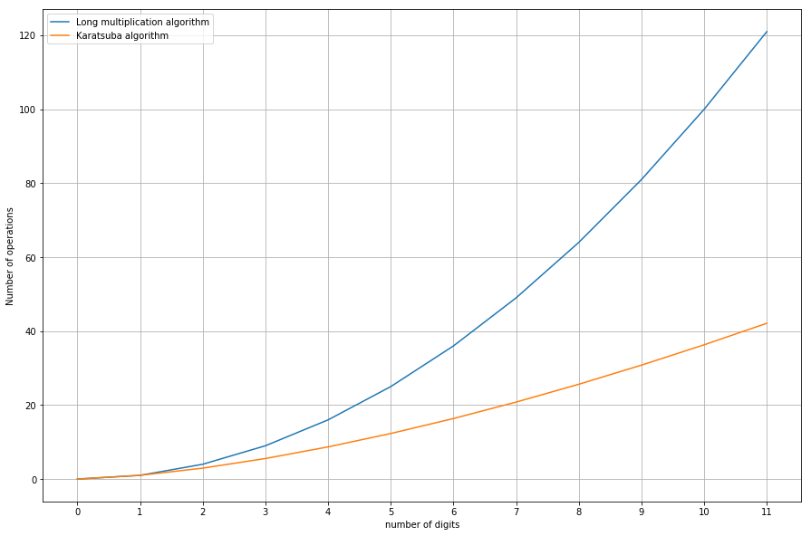

```python
%matplotlib inline

import matplotlib
import numpy as np
import matplotlib.pyplot as plt


xpoints = np.arange(0,12,1)

ypoints = np.power(xpoints, 2)
ypoints2 = np.power(xpoints, 1.56)

plt.figure(figsize=(15, 10))
plt.xlabel("number of digits")
plt.ylabel("Number of operations")

plt.plot(xpoints, ypoints)
plt.plot(xpoints, ypoints2)

plt.xticks(np.arange(0,12,1))

plt.legend(["Long multiplication algorithm", "Karatsuba algorithm"])
plt.grid(True)



plt.show()
```

# “What do we want from a computer algorithm?”

## 1. Correctness and 2. Resource usage optimization (memory and time)

# What Is A Data Structure?

# "A data structure is a way to store and organize data in order to facilitate access and modifications. No single data structure works well for all purposes, and so it is important to know the strengths and limitations of several of them."

[figure not shown]

* source: hellocodeclub.com

# The Programming Language We Will Use In This Lab

[output not shown]

# Information About This Lab

- How many sessions? Check the lab [repository at Github](https://github.com/yahyatawil/HKU-21-22-Data-Structures-Algorithm).

- Lab Material and Assignments? Manged using the lab [repository at Github](https://github.com/yahyatawil/HKU-21-22-Data-Structures-Algorithm).

- Marks? Expected 30-40 marks.

# Lab Rules

- Be positive, motivated and active, if you have any concern or question don't hesitat to contact me any time.

- Missing an assignment deadline (for no acceptable reason) penality is 50% deduction in the respective work mark.

- [Plagiarism](https://www.hcii.cmu.edu/academics/plagiarism-policy) : cheating in any form is not permitted as ethical or educational behavior and will not be tolerated (seriously! first discovered plagiarism, a 10% deduction of your final lab mark. Second discovered plagiarism, 40%. third discovered plagiarism, you will get zero in the lab.)

- The official teaching language is english, thus only English is used and allowed for teaching, commnication, presentations, quizes and assignments.

# Assignment 1